# Lab 2-2

Big Data Analytics and Social Media

26 July 2024

## Overview

In this lab, we will work with the Reddit API. In the first part, we will collect comments from two threads and perform text cleaning. Then, we will create a Document-Term-Matrix from our text data and use it to find the most common words. In the second part, we will tokenise our text data into bigrams (two neighbouring words) and use the bigrams to create a semantic network graph to show the co-occurrence of words among comments.

## Part 1: Reddit Text Analysis

Before we get started, we need to load the following packages into our session:

```r
library(vosonSML)
library(dplyr)
library(tidyr)
library(tidytext)
library(textclean)
library(tm)
library(ggplot2)
library(igraph)
```

### Data Collection

We first choose two threads on Reddit and store them in the variable `thread_urls`. Copy and paste the URLs into a browser to see what these two threads are about.

```r
thread_urls <- c(
  "https://www.reddit.com/r/AusFinance/comments/ymkrlr/",
  "https://www.reddit.com/r/AusFinance/comments/17t45h7/")
```

We don’t need any credentials for Reddit data collection, so we can call the `Authenticate` function right before the `Collect` function. Here, we use the following parameters in the `Collect` function:

- `sort` specifies the Reddit comment sort order, options are: `best`, `top`, `new`, `controversial`, `old`, and `qa` (same as on the Reddit website)
- `waitTime` determines the time in seconds to wait before making another request to the Reddit API (leave this as it is, as we are using the free API)
- `writeToFile` is set to `TRUE` to save the collected data automatically (in your working directory)
- `verbose` is set to `TRUE` to show the download progress while collecting

```r
rd_data <- Authenticate("reddit") |>
  Collect(threadUrls = thread_urls,
          sort = "best",
          waitTime = c(6, 8),
          writeToFile = TRUE,
          verbose = TRUE)
```

Before we do anything else, we should save the data we collected and export it in a format that we can use for visualisation later:

```r
saveRDS(rd_data, file = "rd_data.rds")
write.csv(rd_data, file = "rd_data.csv")
```

Let’s have a look at the data we collected!

```r
View(rd_data)
```

> How many records have you collected?  
> How many fields (columns) can you see?  
> Can you guess what each field stands for?  
> Do you understand the numbers in the *structure* field?

There are usually some rows that have *NA* (no data) in them, so we eliminate those rows from our dataset by using the `complete.cases` function:

```r
rd_data <- rd_data[complete.cases(rd_data), ]
View(rd_data)
```

### Data Cleaning

We now focus on the text data contained in our dataset. We can find the text of each comment in the *comment* field. We apply multiple cleaning steps in succession, passing the output from one cleaning function to the next one with the pipe (`|>`) operator. For details on what each function does, look them up in the documentation of the *textclean* package: https://github.com/trinker/textclean.

> The order in which you apply the cleaning functions matters!!! For example, after you have finished Part 1 of this lab, switch the first two cleaning functions (URL/HTML) with the last two (emoji/emoticon) and see whether you get different results.

```r
clean_text <- rd_data$comment |>
  replace_url() |>
  replace_html() |>
  replace_non_ascii() |>
  replace_word_elongation() |>
  replace_internet_slang() |>
  replace_contraction() |>
  removeNumbers() |>
  removePunctuation() |>
  replace_emoji() |>
  replace_emoticon()
```

Let’s have a look at the first ten comments:

```r
clean_text[1:10]
```

> Do you notice what the cleaning has done to each comment text?

We can convert our `clean_text` vector into a `VCorpus` object, a collection of documents containing text. In this case, each comment is one *document*. We can check that indeed nothing has changed to our text by looking at, for example, the first and fifth entry in our document collection:

```r
text_corpus <- VCorpus(VectorSource(clean_text))

text_corpus[[1]]$content
text_corpus[[5]]$content
```

We continue with some further text pre-processing. We use the following helpful functions from the *tm* package:

- `content_transformer(tolower)` transforms all text to lower case
- `removeWords` with `stopwords` removes stop words
- `stemDocument` applies stemming (this step is optional)
- `stripWhitespace` removes superfluous spaces

```r
text_corpus <- text_corpus |>
  tm_map(content_transformer(tolower)) |>
  tm_map(removeWords, stopwords(kind = "SMART")) |>
  # tm_map(stemDocument) |> # optional
  tm_map(stripWhitespace)
```

Take a look at how the first and fifth entry have changed:

```r
text_corpus[[1]]$content
text_corpus[[5]]$content
```

### Document Term Matrix

In order to find the most common words across all comments, we build a Document Term Matrix. It is basically a table with one row for each document (comment) and a column for each term (word). A cell contains a *1* if the word occurs in that document, otherwise it contains a *0*.

```r
doc_term_matrix <- DocumentTermMatrix(text_corpus)
```

We transform the Document Term Matrix into a data frame so that we visually inspect it and sort it with the most frequently occurring words at the top:

```r
dtm_df <- as.data.frame(as.matrix(doc_term_matrix))
View(dtm_df)

freq <- sort(colSums(dtm_df), decreasing = TRUE)
```

View the top 10 terms and their frequency across all comments:

```r
head(freq, n = 10)
```

Let’s now plot the frequency as a column chart:

```r
word_frequ_df <- data.frame(word = names(freq), freq)
View(word_frequ_df)

ggplot(subset(word_frequ_df, freq > 2), aes(x = reorder(word, -freq), y = freq)) +
  geom_bar(stat = "identity") +
  theme(axis.text.x = element_text(angle = 45, hjust = 1)) +
  ggtitle("Word Frequency") +
  xlab("Words") +
  ylab("Frequency")
```

Since there are many words in our data frame, the chart is not clear. Thus, we choose only the top 11 words and visualise their frequency:

```r
ggplot(subset(word_frequ_df, freq > freq[12]), aes(x = reorder(word, -freq), y = freq)) +
  geom_bar(stat = "identity") +
  theme(axis.text.x = element_text(angle = 45, hjust = 1)) +
  ggtitle("Word Frequency") +
  xlab("Words") +
  ylab("Frequency")
```

> Change the number in the code above from `12` to another number and see how the chart changes.

## Part 2: Reddit word co-occurrence

In Part 1 above, we used a Document Term Matrix to find the most common words in our dataset. In this part, we will look at which words are often occurring together. To start, we save our `clean_text` vector as a data frame so that we can use helpful functions from the *tidytext* package:

```r
clean_df <- data.frame(clean_text)
```

### Bigram Tokenisation

We use the `unnest_tokens` function to tokenise our comment text. Specifically, we split the text into pairs of words (*bigrams*) by stating `n = 2`:

```r
rd_bigrams <- clean_df |> unnest_tokens(output = bigram,
                                       input = clean_text,
                                       token = "ngrams",
                                       n = 2)
```

You can see that we now have all combinations of two neighbouring words per comment:

```r
View(rd_bigrams)
```

We now count the number of occurrences for all bigrams (and split them across two columns, which will help us later):

```r
rd_bigrams_table <- rd_bigrams |>
  count(bigram, sort = TRUE) |>
  separate(bigram, c("left", "right"))

View(rd_bigrams_table)
```

> What can you observe in the results? Do the same words appear at the top as in Part 1 above? If they are different, why is that so?

Next, we remove stopwords to get a more meaningful table and remove rows that have *NA*s:

```r
rd_bigrams_nostops <- rd_bigrams_table |>
  anti_join(stop_words, join_by(left == word)) |>
  anti_join(stop_words, join_by(right == word)) # different to above because now table

View(rd_bigrams_nostops)

rd_bigrams_nostops <- rd_bigrams_nostops[complete.cases(rd_bigrams_nostops), ]

View(rd_bigrams_nostops)
```

> How about now? Do the results look more similar to those for Part 1?

Finally, we don’t want to have too many bigrams with low occurrences, so we keep only those that occur at least twice (`n >= 2`):

```r
rd_bigrams_nostops <- rd_bigrams_nostops |> filter(n >= 2)
View(rd_bigrams_nostops)
```

### Semantic Network Graph

Lastly, we can create a network from the bigram data. Each token (word) in a bigram becomes a node, and an edge exists between two words if they occur together in a bigram. We call such a network a *semantic network*.[^1] We can easily build a network graph structure as follows:

```r
rd_bigram_graph <- graph_from_data_frame(rd_bigrams_nostops, directed = FALSE)
```

Call the `rd_bigram_graph` object to receive information about the structure of your graph:

```r
rd_bigram_graph
```

You will see something similar to this:

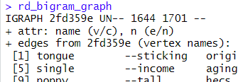

For full details, see the igraph documentation: https://igraph.org/r/doc/print.igraph.html

We can also get the number of nodes and edges, respectively, as follows:

```r
vcount(rd_bigram_graph)
ecount(rd_bigram_graph)
```

We want to remove any loops or multiple edges between the same two words:

```r
rd_bigram_graph <- simplify(rd_bigram_graph)
vcount(rd_bigram_graph)
ecount(rd_bigram_graph)
```

Now we should have a well-defined semantic network graph. We can do a quick visualisation in RStudio:

```r
plot(rd_bigram_graph, vertex.size = 4, edge.arrow.size = 0.5)
```

Obviously, this is not very pretty, so we save the graph to visualise it with other tools later:

```r
write_graph(rd_bigram_graph, file = "RedditBigram.graphml", format = "graphml")
```

To wrap up this lab, let’s run the Page Rank algorithm on our semantic network:

```r
rank_rd_bigram <- sort(page_rank(rd_bigram_graph)$vector, decreasing=TRUE)
rank_rd_bigram[1:5]
```

> How do the Page Rank results compare to the Document Term Matrix frequency and the bigram frequency calculations above?

Finally, let’s save our data for this lab:

```r
save.image(file = "2-2_Lab_Data.RData")
```

[^1]: Note that the edges in a semantic network are *undirected*. This is different to the *actor network* that you have encountered previously, where the edges are *directed* (e.g., from one user to another user, or from one artist to another artist).